# 浅野ゼミナール 夏合宿 2015

2015年度浅野ゼミの夏合宿は、9/13(日)から9/15(火)の日程で行われました。場所は神奈川県の湘南国際村センターです。

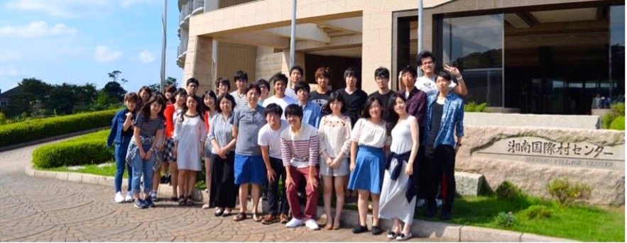

湘南国際村センターで記念撮影

合宿では主に3・4年生による論文の中間発表が行われました。 1日目〜2日目を通してグループごとにそれぞれの研究の結果をプレゼンしました。2年生の中には研究の大元である統計や計量政治に関する知識に差があったにもかかわらず、積極的に意見が挙げられました。2年生は3・4年生の論文発表で多くの知識と興味を得ることができました。大学での授業だけでは学ぶことのできない実践的な部分を多く知ることができる非常に良い機会でした。

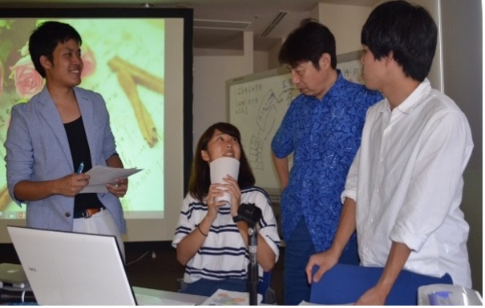

3・4年生による研究発表の風景

[figure not shown]

3・4年生による研究発表の風景

2日目の午後に、2年生によるビブリオバトルが行われました。各々が本を一冊紹介していくビブリオバトルは今回が初めての経験であった人も多く、限られた時間の中で自分が選んだ本をアピールするむずかしさを学びました。終了後はそれぞれの本について、楽しそうに話す様子も見られ、新たな本に出会えた人も多かったのではないでしょうか。

[figure not shown]

2年生によるビブリオバトルの風景

[figure not shown]

2年生によるビブリオバトルの風景

各学年の発表が終了した後は、全学年合同でのビンゴ大会です。豪華賞品も用意され、学年の垣根を越えて楽しめました。普段の大学生活では関わりの少ない人同士も楽しい時間が過ごせました。

[figure not shown]

ビンゴ大会の風景

[figure not shown]

ビンゴ大会の風景

3日間を通して多くの学生が有意義に過ごせた夏合宿だったと思います。3・4年生に引けを取らず、2年生も今後に大いに生かせる合宿になりました。幹事の方はじめ先輩方に感謝します。  
(文責:政経学部 法律政治学科 2年 東山琴美)

### 参加学生の感想.

#### 政経学部 経済学科 3年 荒川萌音.

春合宿に続き、夏合宿もとても有意義なものとなりました。 先輩方の論文発表は非常にレベルが高く興味深いものばかりでした。2年生からの質問は普段のゼミでは出てこないような新しいものもあり、改めて考えさせられることが多くありました。自分が論文を書く際、先輩方の発表や後輩の質問を参考にしたいです。 3年生も論文の中間発表をしましたが、私たちのグループは何度もテーマが白紙に戻り、直前に決まった新しいテーマについて満足のいく発表とはなりませんでした。しかし、今回の発表で先生や先輩方からアドバイスをいただくことが出来たので、より質の良い論文を完成させることが出来るよう努力したいと思います。 2年生のビブリオバトルではそれぞれの個性がよく出ており、おもしろいものでした。緊張感も伝わってきました。普段あまり本を読まないのですが、2年生の本の紹介は心を掴むものばかりで、久しぶりに本を読もうという気持ちになりました。 今回も合宿に参加することができよかったです。後期のゼミも気を引き締めて取り組んでいこうと思います。

#### 政経学部 経済学科 2年 遠藤勇哉

今回の合宿では、3・4年生の先輩方の凄さを感じました。私たち2年生は「統計入門」や「計量政治学」の授業で実証分析の方法を学んできました。しかし、先輩方の論文は私にとって難しく感じました。特に感じたことは、私自身、基本的なことが理解出来ていないということです。今後は基本的なことから勉強を始めていきたいと思います。 また、今回の合宿には立教大学2年生の松浦君も参加しました。松浦君は3・4年生と同じように論文を発表しました。彼の論文発表は非常に分かりやすく、質問にもすぐに答えていました。彼と私には雲泥の差があると感じました。同じ2年生なので彼の存在は2年生にとってすごく刺激になると思います。 自分が3・4年生になった時に、先輩方のような論文が書けるように勉強していきたいです。